# Chemical Dependence Treatment Program Admissions

Deepali Krishna Kashyap

2025-02-16

### **Loading Libraries**

```r
library(tidyverse)
```

```r
library(lubridate)
library(XML)
library(dplyr)
library(stringr)
library(tidyr)
library(ggplot2)
```

# PART 1

#### Create a dataframe with 4 variables. The 4 variables should be doctor_type, doctor_lastname, location, AVG_Rating . The variable doctor_type should contain 4 inputs (PCP, Psychiatrist, Surgeon, Anesthesia) The variable doctor_lastname should contain 4 inputs (Smith, Dame, Jones, Zayas) The variable location should contain 4 inputs (MA, ME, NH, VT) The variable AVG_Rating should contain 4 inputs (7,9,8,9) Print the data frame.

```r
doctor_type <- c("PCP","Psychiatrist", "Surgeon", "Anesthesia")
doctor_lastname <- c("Smith", "Dame", "Jones", "Zayas")
location<- c("MA", "ME", "NH", "VT")
AVG_Rating <- c(7, 9, 8, 9)
doctor_df <-data.frame(doctor_type, doctor_lastname, location, AVG_Rating)

doctor_df
```

```
##    doctor_type doctor_lastname location AVG_Rating
## 1          PCP           Smith       MA          7
## 2 Psychiatrist            Dame       ME          9
## 3      Surgeon           Jones       NH          8
## 4   Anesthesia           Zayas       VT          9
```

#### The code creates a data frame (doctor_df) that stores information about different types of doctors, their last names, locations, and average ratings. It then prints the data frame.

#### Using the dataframe above. Select row 1 in column 2, what was selected? Select rows 2 through 4, what was selected? Select the last column, what was selected?

```r
#select row 1 in column 2
doctor_df[1,2]
```

```
## [1] "Smith"
```

#### To select rows and columns within a Data Frame, we use square brackets.The first argument indicates which row we want to select. In this case, row = 1. The second argument selects the column. In this case, column = 2. For the first iteration, we are retrieving the last name of the first doctor stored, which is ‘Smith’.

```r
#select rows 2 through 4
doctor_df[2:4,]
```

```
##    doctor_type doctor_lastname location AVG_Rating
## 2 Psychiatrist            Dame       ME          9
## 3      Surgeon           Jones       NH          8
## 4   Anesthesia           Zayas       VT          9
```

#### In this case, when we use ‘:’, we are specifying a range. Since this range is in the rows section, we are selecting the rows from 2 to 4 inclusively. In other words, since our Data Frame has only four rows, we are selecting the entire Data Frame except for the first row. The column argument remains empty, indicating that we do not want to select any specific column. We are retrieving all the data for the last three doctors in our Data Frame, including their specialties, last names, locations, and ratings.

```r
#Last column
doctor_df[,4]
```

```
## [1] 7 9 8 9
```

#### Finally, we are selecting only the column located in the fourth position within the Data Frame. We are retrieving only the AVG_ratings for all the doctors.

# PART 2

### Now that we know more about the Chemical Dependence Treatment Program offered by The Office of Addiction Services and Support, we have a better picture of the mission of The Office and their history and requirements to be accepted. From now on, we can understand the data by reading the dictionary file and loading the “.csv” file in our code chunk to observe the structure and dimensions of the dataset.

#### Load the data, directly from the URL Links to an external site, into your R environment.

```r
ny_cd_df <- read.csv("https://query.data.world/s/orm7vayxgdtwvfceewvazzo5psj6wn?dws=00000", header=TRUE, stringsAsFactors=FALSE)
head(ny_cd_df)
```

```
##   Year County.of.Program.Location Program.Category
## 1 2017                     Albany           Crisis
## 2 2017                     Albany           Crisis
## 3 2017                     Albany           Crisis
## 4 2017                     Albany           Crisis
## 5 2017                     Albany           Crisis
## 6 2017                     Albany           Crisis
##                       Service.Type  Age.Group Primary.Substance.Group
## 1 Medically Managed Detoxification 18 thru 24                 Alcohol
## 2 Medically Managed Detoxification 18 thru 24              All Others
## 3 Medically Managed Detoxification 18 thru 24      Cocaine incl Crack
## 4 Medically Managed Detoxification 18 thru 24                  Heroin
## 5 Medically Managed Detoxification 18 thru 24           Other Opioids
## 6 Medically Managed Detoxification 25 thru 34                 Alcohol
##   Admissions
## 1         25
## 2          7
## 3          1
## 4         64
## 5         20
## 6        140
```

```r
# We get the total columns and rows
dim(ny_cd_df)
```

```
## [1] 72463     7
```

```r
# We get the structure of the data frame and the types of variables.
str(ny_cd_df)
```

```
## 'data.frame':    72463 obs. of  7 variables:
##  $ Year                      : int  2017 2017 2017 2017 2017 2017 2017 2017 2017 2017 ...
##  $ County.of.Program.Location: chr  "Albany" "Albany" "Albany" "Albany" ...
##  $ Program.Category          : chr  "Crisis" "Crisis" "Crisis" "Crisis" ...
##  $ Service.Type              : chr  "Medically Managed Detoxification" "Medically Managed Detoxification" "Medically Managed Detoxification" "Medically Managed Detoxification" ...
##  $ Age.Group                 : chr  "18 thru 24" "18 thru 24" "18 thru 24" "18 thru 24" ...
##  $ Primary.Substance.Group   : chr  "Alcohol" "All Others" "Cocaine incl Crack" "Heroin" ...
##  $ Admissions                : int  25 7 1 64 20 140 10 4 244 63 ...
```

#### Evaluate the dataset to determine what data preparation steps are needed and perform them. At a minimum, ensure that you discuss the distribution of the data, outliers and prepare any helpful summary statistics to support your analysis.

#### We will be dealing with a data frame that has around 72,463 observations and 7 variables. The data types in our Data Frame are characters (strings) and integers (integer numbers). We can also use the glimpse() function to see more clearly the data type and some of the values.

```r
glimpse(ny_cd_df)
```

```
## Rows: 72,463
## Columns: 7
## $ Year                       <int> 2017, 2017, 2017, 2017, 2017, 2017, 2017, 2…
## $ County.of.Program.Location <chr> "Albany", "Albany", "Albany", "Albany", "Al…
## $ Program.Category           <chr> "Crisis", "Crisis", "Crisis", "Crisis", "Cr…
## $ Service.Type               <chr> "Medically Managed Detoxification", "Medica…
## $ Age.Group                  <chr> "18 thru 24", "18 thru 24", "18 thru 24", "…
## $ Primary.Substance.Group    <chr> "Alcohol", "All Others", "Cocaine incl Crac…
## $ Admissions                 <int> 25, 7, 1, 64, 20, 140, 10, 4, 244, 63, 230,…
```

#### We also want to obtain a better understanding of the statistics of the Data Frame.

```r
# We can get the statistics from the data frame

summary(ny_cd_df)
```

```
##       Year      County.of.Program.Location Program.Category
##  Min.   :2007   Length:72463               Length:72463
##  1st Qu.:2009   Class :character           Class :character
##  Median :2012   Mode  :character           Mode  :character
##  Mean   :2012
##  3rd Qu.:2015
##  Max.   :2017
##  Service.Type        Age.Group         Primary.Substance.Group
##  Length:72463       Length:72463       Length:72463
##  Class :character   Class :character   Class :character
##  Mode  :character   Mode  :character   Mode  :character
##
##
##
##    Admissions
##  Min.   :   1.00
##  1st Qu.:   3.00
##  Median :   8.00
##  Mean   :  44.62
##  3rd Qu.:  30.00
##  Max.   :2862.00
```

#### Now that we have a better understanding of the data, let’s start retrieving more specific information and identifying things we may need to change for a better data wrangling process.

#### We will make arrangements to change the names of the columns for a better understanding. We will change the data type of the columns that don’t have the most appropriate type. For example, some of the columns are stored as characters when they should be factors because they are representing different categories. Make sure our Data Frame doesn’t contain NA or empty values. If it does, we will treat them separately and take the appropriate approach. In other words, should we delete them? Should we convert the NAs or empty values to 0? We will address the outliers and consider the definition of an outlier. We will need to decide where the boundary of an outlier lies: Is it 3 standard deviations from the mean? Or 1.5 standard deviations from the mean? Finally, we will have a clean Data Frame ready to use and extract information from.

#### We will ensure that the results make sense, and if for some reason we detect an error or irregularity, we will address it and restart the cleaning process

### STEP 1

```r
# Renaming the columns and applying the changes in the data frame. Instead of using "." we prefer to use "-" for the names of the columns.

ny_cd_df <- ny_cd_df %>%
  rename("County" = "County.of.Program.Location",
         "Service_Type" = "Service.Type",
         "Program_Category" = "Program.Category",
         "Age_Group" = "Age.Group",
         "Primary_Substance_Group" = "Primary.Substance.Group")

# Observing the change of names
head(ny_cd_df)
```

```
##   Year County Program_Category                     Service_Type  Age_Group
## 1 2017 Albany           Crisis Medically Managed Detoxification 18 thru 24
## 2 2017 Albany           Crisis Medically Managed Detoxification 18 thru 24
## 3 2017 Albany           Crisis Medically Managed Detoxification 18 thru 24
## 4 2017 Albany           Crisis Medically Managed Detoxification 18 thru 24
## 5 2017 Albany           Crisis Medically Managed Detoxification 18 thru 24
## 6 2017 Albany           Crisis Medically Managed Detoxification 25 thru 34
##   Primary_Substance_Group Admissions
## 1                 Alcohol         25
## 2              All Others          7
## 3      Cocaine incl Crack          1
## 4                  Heroin         64
## 5           Other Opioids         20
## 6                 Alcohol        140
```

```r
# We could also just display the name of the columns
colnames(ny_cd_df)
```

```
## [1] "Year"                    "County"
## [3] "Program_Category"        "Service_Type"
## [5] "Age_Group"               "Primary_Substance_Group"
## [7] "Admissions"
```

### STEP 2

#### We will detect which columns need to be stored in a different type:

#### **“Program_Category”:** is stored as a character but because it refers to a category it should be stored as a factor. **“Service_Type”:** is stored as a character but because it refers to a category it should be stored as a factor. **“Age-Group”:** is stored as a character but because it refers to a category it should be stored as a factor. **“Primary_Substance_Group”:** is stored as a character but because it refers to a category it should be stored as a factor. **“Year”:** is stored as an integer but because it refers to a category (group of years) it should be stored as a factor.

#### The variables: County_of_Program_Location and Admissions will remain the same since their data types are accurate

```r
ny_cd_df$Program_Category <- as.factor(ny_cd_df$Program_Category)
ny_cd_df$Service_Type  <- as.factor(ny_cd_df$Service_Type)
ny_cd_df$Age_Group <- as.factor(ny_cd_df$Age_Group)
ny_cd_df$Primary_Substance_Group <- as.factor(ny_cd_df$Primary_Substance_Group)
ny_cd_df$Year <- as.factor(ny_cd_df$Year)

head(ny_cd_df)
```

```
##   Year County Program_Category                     Service_Type  Age_Group
## 1 2017 Albany           Crisis Medically Managed Detoxification 18 thru 24
## 2 2017 Albany           Crisis Medically Managed Detoxification 18 thru 24
## 3 2017 Albany           Crisis Medically Managed Detoxification 18 thru 24
## 4 2017 Albany           Crisis Medically Managed Detoxification 18 thru 24
## 5 2017 Albany           Crisis Medically Managed Detoxification 18 thru 24
## 6 2017 Albany           Crisis Medically Managed Detoxification 25 thru 34
##   Primary_Substance_Group Admissions
## 1                 Alcohol         25
## 2              All Others          7
## 3      Cocaine incl Crack          1
## 4                  Heroin         64
## 5           Other Opioids         20
## 6                 Alcohol        140
```

### STEP 3

```r
#By using the sum() function, we can count how many NA's are present in our Data Frame. Additionally, we want to check if there are any empty values or spaces entered in any of the cells by using the "|" operator.

sum(is.na(ny_cd_df))
```

```
## [1] 0
```

```r
empty <- sum(ny_cd_df == "" | ny_cd_df == " ")

# Printing the results
print(paste("Number of empty values:", empty))
```

```
## [1] "Number of empty values: 0"
```

```r
# Count duplicate rows
num_duplicates <- sum(duplicated(ny_cd_df))

# Remove duplicates if found
ny_cd_df <- ny_cd_df %>% distinct()

# Print the number of removed duplicate rows
print(paste("Number of duplicate rows removed:", num_duplicates))
```

```
## [1] "Number of duplicate rows removed: 0"
```

### STEP 4

```r
#ADMISSIONS
admissions <- ny_cd_df$Admissions
mean_admissions = mean(admissions)

#Standard deviations
sd_admissions = sd(admissions)
sd_admissions
```

```
## [1] 131.1749
```

```r
#Getting the high outliers and low outliers for the variable admissions.

high_outliers_admissions = mean_admissions + 3 * sd_admissions
high_outliers_admissions
```

```
## [1] 438.1451
```

```r
low_outliers_admissions = mean_admissions - 3 * sd_admissions
low_outliers_admissions
```

```
## [1] -348.9043
```

```r
#Getting the number of outliers considering the values below the low_outliers and above the high_outliers
n_admissions_outliers <- sum(admissions < low_outliers_admissions | admissions > high_outliers_admissions)

#We've got 1380 outliers for "admissions"
n_admissions_outliers
```

```
## [1] 1380
```

```r
# We want now to eliminate the outliers from the column tip_amount. We will use a filter to cleanup the data and then visualize the column before and after the outliers.
ny_cd_df_clean <- ny_cd_df %>%
  filter(admissions >= low_outliers_admissions & admissions <= high_outliers_admissions)

#Comparing both data frames:
head(ny_cd_df_clean)
```

```
##   Year County Program_Category                     Service_Type  Age_Group
## 1 2017 Albany           Crisis Medically Managed Detoxification 18 thru 24
## 2 2017 Albany           Crisis Medically Managed Detoxification 18 thru 24
## 3 2017 Albany           Crisis Medically Managed Detoxification 18 thru 24
## 4 2017 Albany           Crisis Medically Managed Detoxification 18 thru 24
## 5 2017 Albany           Crisis Medically Managed Detoxification 18 thru 24
## 6 2017 Albany           Crisis Medically Managed Detoxification 25 thru 34
##   Primary_Substance_Group Admissions
## 1                 Alcohol         25
## 2              All Others          7
## 3      Cocaine incl Crack          1
## 4                  Heroin         64
## 5           Other Opioids         20
## 6                 Alcohol        140
```

```r
head(ny_cd_df)
```

```
##   Year County Program_Category                     Service_Type  Age_Group
## 1 2017 Albany           Crisis Medically Managed Detoxification 18 thru 24
## 2 2017 Albany           Crisis Medically Managed Detoxification 18 thru 24
## 3 2017 Albany           Crisis Medically Managed Detoxification 18 thru 24
## 4 2017 Albany           Crisis Medically Managed Detoxification 18 thru 24
## 5 2017 Albany           Crisis Medically Managed Detoxification 18 thru 24
## 6 2017 Albany           Crisis Medically Managed Detoxification 25 thru 34
##   Primary_Substance_Group Admissions
## 1                 Alcohol         25
## 2              All Others          7
## 3      Cocaine incl Crack          1
## 4                  Heroin         64
## 5           Other Opioids         20
## 6                 Alcohol        140
```

### STEP 5

### Plot visualization:

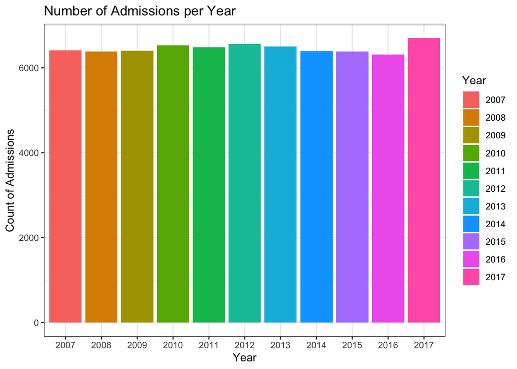

```r
ggplot(ny_cd_df_clean, aes(x = Year, fill = Year)) +
  geom_bar() +
  theme_bw() +
  labs(title = "Number of Admissions per Year",
       x = "Year",
       y = "Count of Admissions",
       fill = "Year")
```

#### The graph is a bar chart representing the Number of Admissions per Year from 2007 to 2017. Each bar corresponds to a specific year and is color-coded according to the legend on the right. The x-axis represents the years, while the y-axis represents the count of admissions.

#### **Tibble 1:** county which contains the name of all counties and their respective county code (link)Links to an external site. (which is the primary key). ensure that your data frame does not contain duplicate counties and ensure that your dataframe contains all counties in the data. The county codes provided in the link above are intended as a starting point. Remember that primary keys must be unique.

#### Data Cleaning and Transformation - Extracting County Codes In this part of the analysis, we are focusing on cleaning and transforming the data for better analysis. Specifically, we are working with the County column in the dataset to:

#### Extract unique counties Generate a standardized code for each county Display the cleaned data for verification

```r
# Extract Unique Counties with County Codes
county <- ny_cd_df_clean %>%
  select(County) %>%
  distinct() %>%
  mutate(county_code = toupper(substr(County, 1, 2)))  # Generate county code using first 2 letters

# Display cleaned county data
head(county)
```

```
##     County county_code
## 1   Albany          AL
## 2    Bronx          BR
## 3   Broome          BR
## 4 Dutchess          DU
## 5     Erie          ER
## 6    Kings          KI
```

#### **Tibble 2:** program_category: which contains a unique identifier and the name of the program category. ensure that your data frame does not contain duplicates. The codes can be numeric (e.g. auto incremented).

#### Data Cleaning for Program Categories - In this part of the analysis, we focus on cleaning and transforming the Program Category column for better analysis. We perform the following steps:

#### Extract unique program categories Generate a standardized code for each program category Display the cleaned data for verification

```r
# Extract Unique Program Categories
program_category <- ny_cd_df_clean %>%
  select(Program_Category) %>%
  distinct() %>%
  mutate(program_code = toupper(substr(Program_Category, 1, 2)))  # Assign unique numeric code

# Display cleaned program_category data
head(program_category)
```

```
##           Program_Category program_code
## 1                   Crisis           CR
## 2                Inpatient           IN
## 3 Opioid Treatment Program           OP
## 4               Outpatient           OU
## 5              Residential           RE
```

#### We want to ensure that each program category appears only once in the dataset.

#### We selected the Program_Category column from the original dataset, which contains multiple entries for the same category. By using the distinct() function, we removed duplicates, leaving only unique program categories. substr(Program_Category, 1, 2): We extracted the first two letters of each program category. This gives us a concise, standardized code for each category. toupper(): We converted these letters to uppercase to ensure consistency across the dataset. The head(program_category) function displays the first few rows of the cleaned dataset.

#### **Tibble 3:** primary_substance_group: which contains a unique identifier and the name of the substance. ensure that your data frame does not contain duplicates. The codes can be numeric (e.g. auto incremented).

#### Data Cleaning and Transformation for Primary Substance Group - In this section of the analysis, we are cleaning and transforming the Primary Substance Group data to:

#### Extract unique substance categories Generate a standardized code for each substance group (e.g., “Heroin” becomes “H”) Display the cleaned data with substance codes for verification.

```r
primary_substance_group <- ny_cd_df_clean %>%
  select(Primary_Substance_Group) %>%
  distinct() %>%
  mutate(
    substance_code = case_when(
      Primary_Substance_Group == "All Others" ~ "AO",  # Assign code 'AO' to "All Others"
      Primary_Substance_Group == "Heroin" ~ "H",       # Assign code 'H' to "Heroin"
      Primary_Substance_Group == "Cocaine incl Crack" ~ "CC",  # Assign code 'C' to "Cocaine incl Crack"
      Primary_Substance_Group == "Alcohol" ~ "A",      # Assign code 'A' to "Alcohol"
      Primary_Substance_Group == "Other Opioids" ~ "O",  # Assign code 'O' to "Other Opioids"
      Primary_Substance_Group == "Marijuana incl Hashish" ~ "MH",  # Assign code 'M' to "Marijuana incl Hashish"
    )
  )

# Display cleaned primary_substance_group data with substance codes
head(primary_substance_group)
```

```
##   Primary_Substance_Group substance_code
## 1                 Alcohol              A
## 2              All Others             AO
## 3      Cocaine incl Crack             CC
## 4                  Heroin              H
## 5           Other Opioids              O
## 6  Marijuana incl Hashish             MH
```

#### We want to eliminate any duplicates and work with only the unique substance categories in the dataset.

#### We selected the Primary_Substance_Group column from the dataset. The distinct() function removed any duplicate entries, leaving only unique substance categories.

#### We want to generate unique substance codes that will make the data easier to work with. 1. We used the case_when() function to create the substance_code column. Each substance group was assigned a corresponding code:

#### “All Others” → “AO” “Heroin” → “H” “Cocaine incl Crack” → “CC” “Alcohol” → “A” “Other Opioids” → “O” “Marijuana incl Hashish” → “MH”

#### To verify that the data transformation was performed correctly.

#### The head(primary_substance_group) function displays the first few rows of the cleaned dataset.

#### **Tibble 4:** admissions_data which contain the details on the reported number of admissions — excluding the data that resides in the county, program_category and primary_substance_group tibbles/data frames; you should instead include a column with their respective foreign keys.

#### Clean, merge, and transform admissions_data - The goal of this step is to clean, merge, and transform data for a more structured and effective analysis.

```r
admissions_data <- ny_cd_df_clean %>%
  left_join(county, by = "County") %>%
  left_join(program_category, by = "Program_Category") %>%
  left_join(primary_substance_group, by = "Primary_Substance_Group")


# Display the final merged data
admissions_data <- admissions_data%>%
  select(Year, county_code, program_code, Service_Type, Age_Group, substance_code, Admissions)

#Conversion to a factor

admissions_data$county_code <- as.factor(admissions_data$county_code)
admissions_data$program_code  <- as.factor(admissions_data$program_code)
admissions_data$substance_code <- as.factor(admissions_data$substance_code)

head(admissions_data)
```

```
##   Year county_code program_code                     Service_Type  Age_Group
## 1 2017          AL           CR Medically Managed Detoxification 18 thru 24
## 2 2017          AL           CR Medically Managed Detoxification 18 thru 24
## 3 2017          AL           CR Medically Managed Detoxification 18 thru 24
## 4 2017          AL           CR Medically Managed Detoxification 18 thru 24
## 5 2017          AL           CR Medically Managed Detoxification 18 thru 24
## 6 2017          AL           CR Medically Managed Detoxification 25 thru 34
##   substance_code Admissions
## 1              A         25
## 2             AO          7
## 3             CC          1
## 4              H         64
## 5              O         20
## 6              A        140
```

```r
tail(admissions_data)
```

```
##       Year county_code program_code        Service_Type    Age_Group
## 71078 2007          WE           RE Res Rehab for Youth 55 and Older
## 71079 2007          WE           RE Res Rehab for Youth     Under 18
## 71080 2007          WE           RE Res Rehab for Youth     Under 18
## 71081 2007          WE           RE Res Rehab for Youth     Under 18
## 71082 2007          WE           RE Res Rehab for Youth     Under 18
## 71083 2007          WE           RE Res Rehab for Youth     Under 18
##       substance_code Admissions
## 71078             CC          1
## 71079              A          6
## 71080             AO          1
## 71081             CC          4
## 71082              H          1
## 71083             MH        236
```

#### We are merging multiple datasets to combine relevant data into a single dataframe, admissions_data, for better analysis. Joining the datasets using common columns:

#### County: We join by the County column. Program Category: We join by Program_Category. Primary Substance Group: We join by Primary_Substance_Group.

#### Once the data is merged, we keep only the relevant columns for our analysis:

#### Year County Code Program Code Service Type Age Group Substance Code Admissions This helps reduce unnecessary data and focus on key variables.

#### We convert categorical columns (such as county_code, program_code, and substance_code) to factors. After performing the necessary transformations, we check the data to ensure everything is in order. We use the following functions to display the first and last rows of the data:

#### head(admissions_data): View the first few rows. tail(admissions_data): View the last few rows. This ensures that the data has been correctly merged and transformed.

#### Create a function called annualAdmissions() that derives the total number of reported admissions that transpired each year, for the entire state of NY and displays the results using a line chart. Annotate the chart to show the year with the highest number of admissions. Note: the year should be on the x-axis and the number of admissions on the y-axis. Explain the chart.

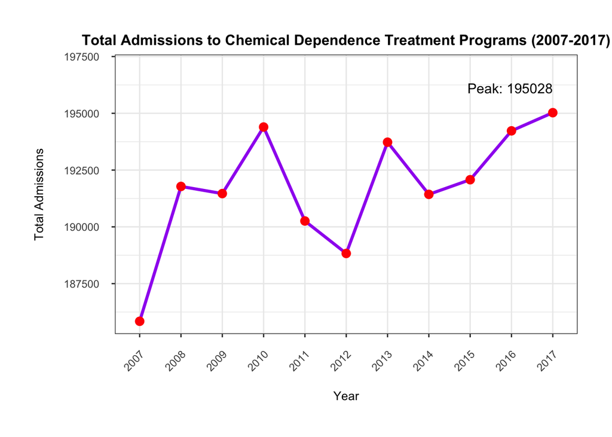

```r
# Define the function
annualAdmissions <- function(ny_cd_df_clean) {

  # Aggregate total admissions by year
  admissions_by_year <- ny_cd_df_clean %>%
    group_by(Year) %>%
    summarise(total_admissions = sum(Admissions, na.rm = TRUE))%>%
    arrange(Year)

  # Identify the year with the highest admissions
  max_year <- admissions_by_year %>%
    filter(total_admissions == max(total_admissions))

  # Create the line chart
  ggplot(admissions_by_year, aes(x = factor(Year), y = total_admissions)) +
    geom_line(group = 1, color = "purple", size = 1.2) +
    geom_point(color = "red", size = 3) +
    geom_text(data = max_year, aes(label = paste("Peak:", total_admissions)),
              vjust = -2, hjust = 1, size = 4, color = "black") +
    #scale_x_continuous(breaks = seq(2007, 2019, by = 1)) +
    scale_y_continuous(limits = c(min(admissions_by_year$total_admissions),
                              max(admissions_by_year$total_admissions) + 2000)) +
    labs(title = "Total Admissions to Chemical Dependence Treatment Programs (2007-2017)",
         x = "Year",
         y = "Total Admissions") +
    theme_bw() +
    theme(
      plot.title = element_text(hjust = 0.5, size = 12, face = "bold"),
      axis.title = element_text(size = 10),
      axis.text.x = element_text(angle = 45, hjust = 1,margin = margin(t = 10)),
      plot.margin = margin(1, 1, 1, 1, "cm"),
      axis.text.y = element_text(margin = margin(r = 10)),
    axis.title.x = element_text(margin = margin(t = 15)),
    axis.title.y = element_text(margin = margin(r = 15))
    )
}

# Run the function with admissions_data
annualAdmissions(ny_cd_df_clean)
```

#### Analyze the percentage of admissions for each county and visualize the results for the top 5 counties using a bar chart. Explain the results. Note: ensure that you join any related dataframes/ tibbles.

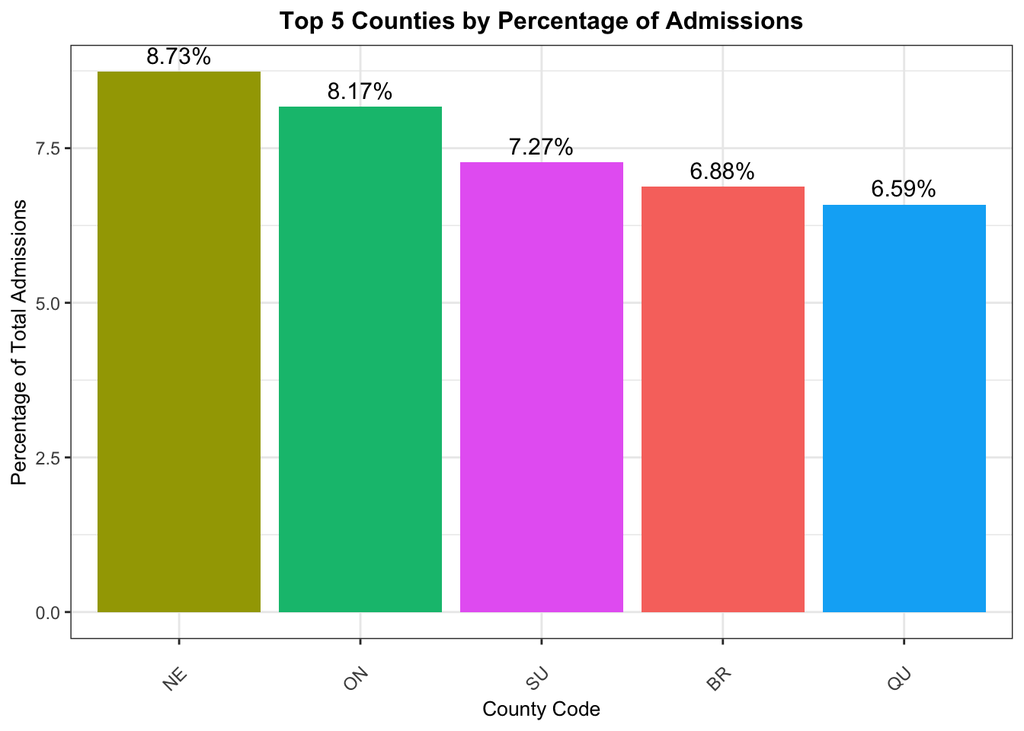

```r
# Load necessary libraries
library(dplyr)
library(ggplot2)

# Defining the function
countyAdmissionsAnalysis <- function(admissions_data) {

  # seperate total admissions by county
  county_admissions <- admissions_data %>%
    group_by(county_code) %>%
    summarise(total_admissions = sum(Admissions, na.rm = TRUE)) %>%
    arrange(desc(total_admissions))

  # Calculating percentage of total admissions for each county
  total_statewide_admissions <- sum(county_admissions$total_admissions, na.rm = TRUE)
  county_admissions <- county_admissions %>%
    mutate(percentage = (total_admissions / total_statewide_admissions) * 100)

  # Selecting top 5 counties
  top_5_counties <- county_admissions %>%
    slice_max(order_by = total_admissions, n = 5)

  # bar chart
  ggplot(top_5_counties, aes(x = reorder(county_code, -total_admissions), y = percentage, fill = county_code)) +
    geom_bar(stat = "identity") +
    geom_text(aes(label = paste0(round(percentage, 2), "%")), vjust = -0.5, size = 4) +
    labs(title = "Top 5 Counties by Percentage of Admissions",
         x = "County Code",
         y = "Percentage of Total Admissions") +
    theme_bw() +
    theme(
      plot.title = element_text(hjust = 0.5, size = 12, face = "bold"),
      axis.title = element_text(size = 10),
      axis.text.x = element_text(angle = 45, hjust = 1, margin = margin(t = 10)),
      legend.position = "none"
    )
}

# Run the function with admissions_data
countyAdmissionsAnalysis(admissions_data)
```

### Filter the data, using a regular expression, and extract all admissions to the various “Rehab” facilities; i.e. your regex should match all facilities that include the word rehab, rehabilitation, etc. Using the filtered data, identify which substance is the most prominent among each age group. Visualize and explain the results.

```
##   Year county_code program_code             Service_Type  Age_Group
## 1 2017          AL           IN Inpatient Rehabilitation 18 thru 24
## 2 2017          AL           IN Inpatient Rehabilitation 18 thru 24
## 3 2017          AL           IN Inpatient Rehabilitation 18 thru 24
## 4 2017          AL           IN Inpatient Rehabilitation 18 thru 24
## 5 2017          AL           IN Inpatient Rehabilitation 18 thru 24
## 6 2017          AL           IN Inpatient Rehabilitation 18 thru 24
##   substance_code Admissions
## 1              A         11
## 2             AO          2
## 3             CC          4
## 4              H         21
## 5             MH          6
## 6              O          5
```

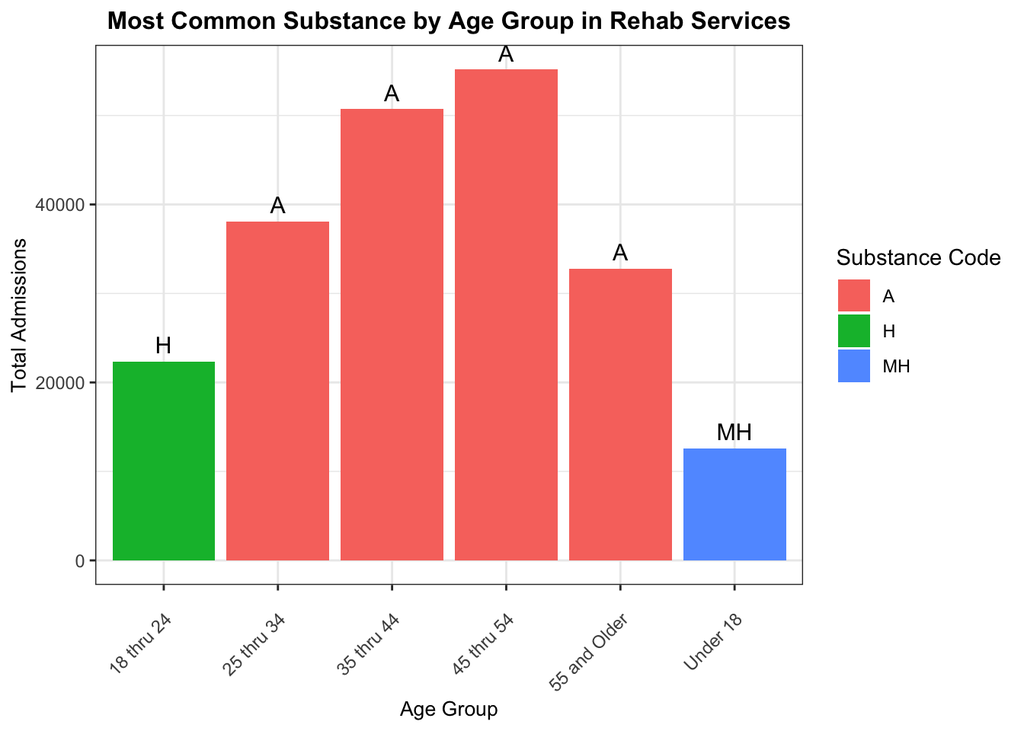

```r
# Define the function
rehabAdmissionsAnalysis <- function(ny_cd_df_clean) {

  # Filter admissions related to rehab facilities using regex on Service_Type
  rehab_admissions <- ny_cd_df_clean %>%
    filter(str_detect(Service_Type, regex("rehab|rehabilitation", ignore_case = TRUE)))

   # Print the first few rows of rehab_admissions
  print(head(rehab_admissions))  # Displays the first 6 rows

  # Identify the most common substance for each age group
  top_substance_by_age <- rehab_admissions %>%
    group_by(Age_Group, substance_code) %>%
    summarise(total_admissions = sum(Admissions, na.rm = TRUE), .groups = "drop") %>%
    group_by(Age_Group) %>%
    slice_max(order_by = total_admissions, n = 1, with_ties = FALSE)  # Get the top substance for each age group

  # Bar chart visualization for all age groups
  ggplot(top_substance_by_age, aes(x = Age_Group, y = total_admissions, fill = substance_code)) +
    geom_bar(stat = "identity", position = "dodge") +  # Use "dodge" to separate bars for each age group
    geom_text(aes(label = substance_code), vjust = -0.5, size = 4, position = position_dodge(width = 0.9)) +  # Add labels for each bar
    labs(title = "Most Common Substance by Age Group in Rehab Services",
         x = "Age Group",
         y = "Total Admissions",
         fill = "Substance Code") +
    theme_bw() +
    theme(
      plot.title = element_text(hjust = 0.5, size = 12, face = "bold"),
      axis.title = element_text(size = 10),
      axis.text.x = element_text(angle = 45, hjust = 1, margin = margin(t = 10))
    )

}

# Run the function
rehabAdmissionsAnalysis(admissions_data)
```

#### The bar chart shows the most common substance for each age group in rehab services. In 18-24 age groups, the most common substance is H (Heroin) (green bar). In 25+ age groups, the most common substance is A (likely Alcohol) (red bars), peaking in the 45-54 age group. And in Under 18, the most common substance is MH (blue bar). These results suggest that younger individuals (18-24) are more affected by heroin use, while older individuals struggle more with alcohol addiction.